# 2b — The Robot as Code

Which numbers are the body? · SOC4180 Robot and AI

Hong Jeong

## Last class, one leg. This class, the whole robot.

Week 2 answered **“where is the foot?”** from six angles. It never said *which six numbers* those were, and it never touched the other twenty-three.

Today the robot stops being a picture and becomes a **data structure you can read**:

1. What is the robot, as data? — one tree, five chains.
2. Which numbers are which body part? — `qpos` is a map.
3. What does the code in `soc4180/` actually do? — three ideas, repeated.

Then, in the lab, you will pose **every** part of the robot by name, and learn the body by moving it.

## Setting up

```
nbody 31   njnt 30   nsite 4
nq    36   nv   35   nu    29
```

Six numbers describe the entire robot’s *shape as data*:

- **`nbody` 31** rigid links, one of them the `world`
- **`njnt` 30** joints — 1 floating base + **29 hinges**
- **`nq` 36 / `nv` 35** — the state, in position and in velocity space
- **`nu` 29** actuators, one per hinge
- **`nsite` 4** — two feet and two IMUs, and *nothing else*

## The robot is a tree

Every body has exactly **one parent**. That is not a convention, it is the definition: `model.body_parentid` is the whole skeleton.

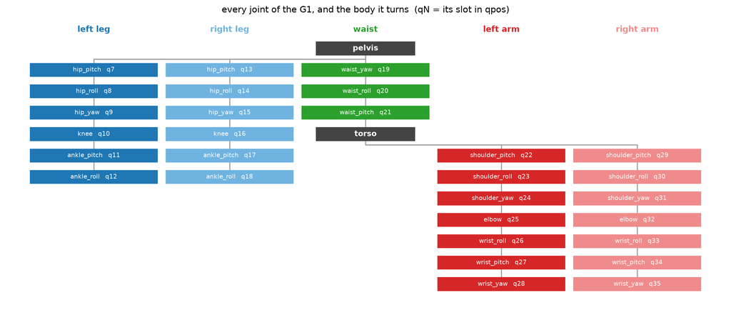

## Five chains, one pelvis

Read the tree again and the robot’s whole layout falls out of it:

```
chain      joints   qpos slots   qvel slots
left_leg        6     7..12        6..11
right_leg       6    13..18       12..17
waist           3    19..21       18..20
left_arm        7    22..28       21..27
right_arm       7    29..35       28..34

joints in the chains: 29  nu: 29
```

$6 + 6 + 3 + 7 + 7 = 29$, and that is **exactly `nu`**. There is nothing else — no head joint, no hands, no neck. The “head” you see in the render is welded to the torso.

Three facts you will use all term:

- The legs hang off the **pelvis**; the arms hang off the **torso**, which is three waist joints further up. So the waist moves both arms and neither leg.
- Every chain’s joints are **contiguous in `qpos`**, in root-to-tip order.
- A chain is a **path in the tree**. `kinematics.LEG_CHAIN` from week 2 is exactly the left-hand column of that diagram.

## `qpos` is a map of the body

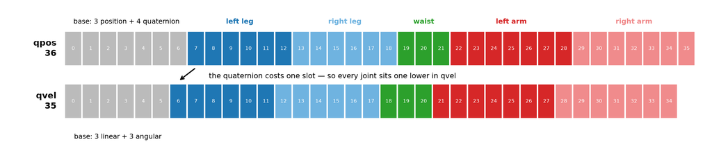

The body part **is** a slice. `data.qpos[22:29]` is the left arm, and it is the left arm on every G1 in the world, because the MJCF says so.

## The off-by-one that never raises

Week 2 met this as `leg_qpos_indices` returning `7..12` while `leg_dof_indices` returns `6..11`. Now you can see why, and that it is true of the **whole** robot:

```
left_hip_pitch     qpos  7   qvel  6
waist_yaw          qpos 19   qvel 18
left_elbow         qpos 25   qvel 24
right_wrist_yaw    qpos 35   qvel 34

qpos index minus qvel index, over all 29 joints: {1}
```

**Always one.** The floating base spends 7 numbers on position and 6 on velocity, because you cannot store a 3-D rotation in 3 numbers without a singularity (week 2’s gimbal lock), but its *rate* is an honest 3-vector.

The danger is that both indices are valid. Use a `qvel` index on `qpos` and you silently read the **neighbouring joint** — an elbow where you meant a shoulder. Nothing raises. Nothing warns. The robot simply does the wrong thing.

## Name the joint; do not count the slots

Counting slots by hand is how that bug gets written. So `soc4180.bodies` does the counting, and you write names:

```
left elbow now: 1.2
left arm now:   [0.  0.3 0.  1.2 0.  0.  0. ]
both knees:     [0.698 0.698] rad
```

Three things `set_pose` does, and each one is a decision you would otherwise make every time:

- `left_elbow` → `left_elbow_joint` → joint id → `jnt_qposadr` → slot 25.
- **Resets to the `stand` keyframe first**, so a pose is a complete description and not a mystery accumulated from earlier cells. Pass `reset=None` to layer.
- Calls `mj_forward`, so the answer is ready the instant the call returns.

## What `mj_forward` actually does

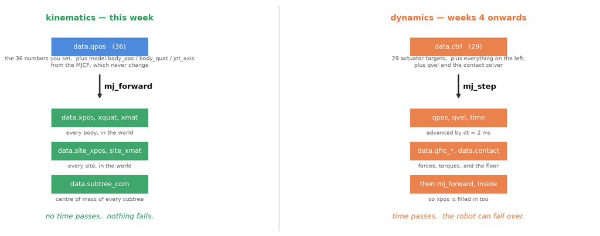

Everything this week is the **left** path. `ctrl` appears nowhere — which is exactly why the viewer’s Control sliders look broken in a kinematic script until you wire them onto `qpos` yourself.

## Four poses, four lines

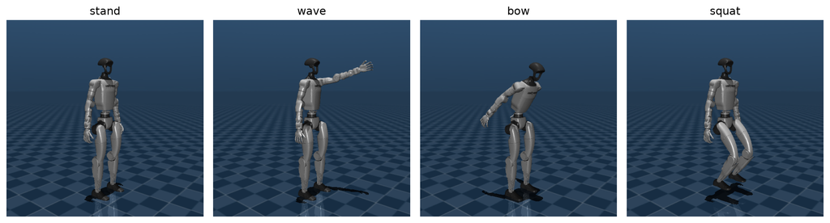

Read the `squat` entry again: **a chain takes one number per joint, root to tip** — hip pitch, hip roll, hip yaw, knee, ankle pitch, ankle roll. The pitch angles sum to zero, which is what keeps the foot level.

## …and the squat is floating

Look at the fourth frame: the shadow is on the floor and the feet are not.

```
foot site standing : 0.0331 m
foot site squatting: 0.1443 m
lifted by          : 0.1112 m
pelvis height      : 0.7900 m   (unchanged — you never moved it)
```

This is week 2’s warning again, now for the whole body: **`set_pose` places a pose; it does not settle a robot.** Bending the knees with the pelvis pinned shortens the legs and lifts the feet. A real squat lowers the pelvis by the same amount — which is exactly what week 4’s walking controller spends its time deciding, and week 3’s IK is how it gets there.

## Every joint, and what it moves

Turn one joint by $0.1$ rad ($5.7°$) from `stand` and measure how far five landmarks travel. This is week 2’s Jacobian bar chart, for the entire robot:

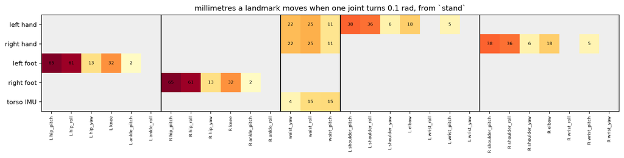

## The grey is the tree

The blank cells are not small numbers. They are **zero to the last bit of a double** — the largest of them is $7 \times 10^{-15}$ mm, which is float arithmetic, not movement. Their pattern is the tree diagram from the start of the deck, redrawn in numbers:

- A **leg** joint moves one foot and *nothing else* — not the other foot, not a hand, not the torso. The legs are separate branches.
- A **waist** joint moves **both hands and neither foot**. Everything above the waist is downstream of it; everything below is not.
- An **arm** joint moves one hand and stops there. Arms are leaves.
- Left and right agree to the millimetre: hip pitch $65$ and $65$, shoulder pitch $38$ and $38$.

## Three joints that move nothing at all

```
left_ankle_roll    +0.5 rad -> moves  0.00000 mm,  rotates  28.6 deg
left_wrist_roll    +0.5 rad -> moves  0.00000 mm,  rotates  28.6 deg
left_wrist_yaw     +0.5 rad -> moves  0.00000 mm,  rotates  28.6 deg
```

Zero to every decimal place, because **the landmark sits on the joint’s own axis** — spinning a point about a line through itself does not move it. Week 2 found this once, as the `ankle_roll` column of zeros in the position Jacobian. It is a property of where the MJCF author put the body origin, not of the robot.

The joints are not useless: they *rotate*. Position is only half of a pose, and next week’s IK solves both.

## Left and right, and the 10 micrometres

Mirroring a humanoid negates $y$. Rotations about $x$ (**roll**) and $z$ (**yaw**) reverse; rotations about $y$ (**pitch**) do not. The MJCF’s own `stand` keyframe says so:

```
stand, left arm : [0.2  0.2  0.   1.28 0.   0.   0.  ]
stand, right arm: [ 0.2  -0.2   0.    1.28  0.    0.    0.  ]

mirror(pose) = {'right_shoulder_pitch': -0.6, 'right_shoulder_roll': -0.9, 'right_elbow': 1.1}

left hand  [0.241521 0.393198 0.965041]
right hand [ 0.241521 -0.393188  0.965041]
disagreement after negating y: 10.0 micrometres
```

Not $10^{-16}$ — **10 µm**. The robot is not perfectly symmetric, and the residual is one number in the MJCF: the left shoulder sits at $y = +0.100220$ and the right at $y = -0.100210$. A CAD rounding artefact, one part in ten thousand, and now you know it is in the model and not in your code.

## The package, in one picture

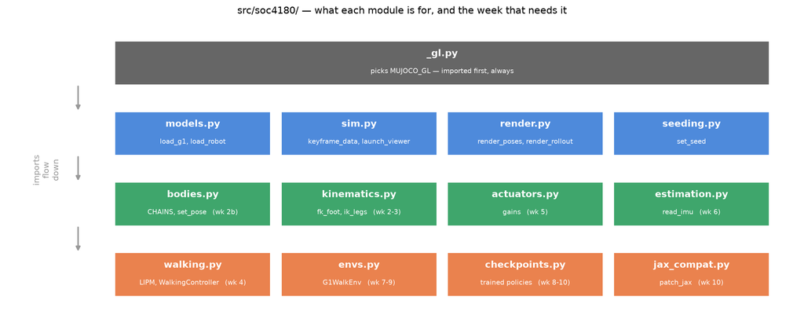

The arrow direction is a rule, not a drawing: **`_gl` must be imported before anything that imports `mujoco`**, because MuJoCo reads `MUJOCO_GL` once, at import. Get that order wrong and rendering works on Windows and dies on Colab.

## `bodies.py` is three ideas

Open it. Four hundred words of docstring around three things you have already seen:

```
joint id 19   qpos slot 25   qvel column 24
left hand now at [-0.0023  0.2218  0.7221]
soc4180.set_pose does exactly this, from the name alone
```

`CHAINS` is a hand-written table, and it is hand-written **on purpose**: the grouping into “left arm” and “waist” is anatomy, and the model does not record it. MuJoCo knows `left_elbow_joint`’s parent is `left_shoulder_yaw_link`; it has no idea that humans call the assembly an arm.

**Everything else in the file is error messages.** Read `_full_name` and count how many lines exist only so that a typo says *“no joint named ‘left_ellbow’”* instead of failing somewhere else entirely.

## `kinematics.fk_foot` walks that diagram

Week 2’s twelve lines, read against the tree:

```python
pos = qpos[:3].copy()                       # start at the pelvis
rot = quat2mat(qpos[3:7])                   #   (the floating base, slots 0..6)

for bid in leg_chain(model, side):          # one column of the tree diagram
    pos = pos + rot @ model.body_pos[bid]   # the fixed offset from the parent
    rot = rot @ quat2mat(model.body_quat[bid])
    jnt = model.body_jntadr[bid]
    if jnt >= 0:
        rot_j = axis_angle(model.jnt_axis[jnt], qpos[model.jnt_qposadr[jnt]])
        pos = pos + rot @ (anchor - rot_j @ anchor)
        rot = rot @ rot_j                   # then the joint's own rotation
```

Three observations that make it readable:

- `leg_chain` returns **body ids down one branch** — the loop is a walk from the pelvis to the foot, one box per iteration.
- `model.body_pos` has **no `x`**: it is the MJCF’s declared offset from the parent, constant. `data.xpos` has one: computed, in world coordinates.
- `qpos[model.jnt_qposadr[jnt]]` is `joint_index` written out. Slot, not id.

Point the same loop down `CHAINS["left_arm"]` and you have arm kinematics. That is exercise 5.

## Exercises

**Warm-up**

1. **Predict the blanks.** Before running anything, say which landmarks `right_hip_yaw` moves, and which `waist_roll` moves. Then check against the heat map.
2. **Name a slot.** Without calling `joint_index`, say which `qpos` slot `right_elbow_joint` uses, from the strip diagram alone. Then verify.
3. **Break it on purpose.** Set `data.qpos[B.dof_index(model, "left_knee")]` to `1.0` and render. Which joint actually moved, and why did nothing complain?

**Main**

4. **A pose of your own.** Write a `salute`, a `T-pose`, and a `lunge` as `set_pose` calls, and render all three in one figure. No number may be typed as a slot index.
5. **Arm kinematics.** Copy `fk_foot` and point it down `CHAINS["left_arm"]`, ending at `left_wrist_yaw_link` rather than a site. Check it against `data.xpos`. You should reach $10^{-16}$ again.
6. **Mirror a whole chain.** `mirror` takes a dict of joints. Write `mirror_chain(angles, chain)` that mirrors a seven-number arm list, and prove it by comparing hand positions as the slide does.
7. **Un-float the squat.** Lower `data.qpos[2]` until the squatting foot sits at the same height as the standing one. How much did the pelvis drop, and how does it compare with the foot lift you measured?

**Harder**

8. **Reach.** Sample the left arm’s seven joints uniformly inside `jnt_range` and plot the hand’s reachable set. Compare its volume with the leg’s.
9. **Rebuild the heat map with `mj_jacBody`.** MuJoCo will give you all 29 columns analytically, with no nudge at all. Do the numbers agree, and which of the two do you trust near a joint limit?
10. **Find the asymmetry yourself.** Loop over every `left_*` body, compare `body_pos` with its `right_*` twin under $y \to -y$, and print any disagreement. There is exactly one.

## Lab class: on your laptop

```bash
uv run weeks/02b-robot-as-code/lab_body.py
```

Every part of the robot, by name. `1`–`5` highlight a chain (yellow spheres root to tip, white at its landmark), `M` mirrors the pose, `ENTER` prints it as a pasteable `set_pose(...)` call, `R` is `stand`; the sliders move joints directly, nothing is simulated. Poses are dictionaries of joint names — no slot indices anywhere. The code is complete and explained.

| Step | Do | Right looks like |
| --- | --- | --- |
| 1 | `1`–`5` | each chain named aloud before the highlight appears |
| 2 | drag one slider per chain | the landmarks that move, predicted first; the heat map is the answer key |
| 3 | three poses in `POSES`, by name | the robot takes them |
| 4 | a left-arm pose, then `M` | roll and yaw flipped sign, pitch did not |
| 5 | left hand above the right foot, `ENTER` | the printed call, pasted into the notebook |

## Lab class: `anatomy.py`, the robot as data

```bash
uv run weeks/02b-robot-as-code/anatomy.py                 # the five chains, qpos / qvel map, ranges
uv run weeks/02b-robot-as-code/anatomy.py --nudge waist   # one row of the heat map, measured live
uv run weeks/02b-robot-as-code/anatomy.py --pose left_shoulder_roll=0.8 left_elbow=1.2 --mirror
```

```
chain        joint                         qpos  qvel   range (rad)
left_leg     left_hip_pitch_joint             7     6   [-2.53, +2.88]
...
waist: each joint +0.1 rad from `stand`; landmark motion in mm
joint                            left foot   right foot    torso IMU   left wrist  right wrist
waist_yaw_joint                        0.0          0.0          4.4         22.2         22.2
waist_pitch_joint                      0.0          0.0         15.3         11.4         11.4
```

| Step | Does | Calls |
| --- | --- | --- |
| 2 | the chain table: slot, slot − 1, range | `bodies.CHAINS`, `joint_index`, `dof_index`, `jnt_range` |
| 3 | nudge one joint at a time, measure five landmarks | `set_pose`, `site_xpos`, `xpos` |
| 4 | a named pose, mirrored | `set_pose`, `mirror`, `chain_of` |
| 5 | show it, chain highlighted | `launch_viewer(passive=True)`, `chain_bodies`, `user_scn` |

## What you now know

**The robot is a tree, and `qpos` is that tree flattened.**

| Question | Where the answer lives |
| --- | --- |
| What parts are there? | `model.body_parentid` — 31 bodies, one parent each |
| Which numbers are the arm? | `qpos[22:29]`, or `CHAINS["left_arm"]` by name |
| What does this joint move? | everything downstream of it, and nothing else |
| Where is it all now? | `mj_forward`, then `xpos` / `site_xpos` |
| Why did it not move? | the landmark is on the joint’s own axis |
| Why is it not symmetric? | 10 µm of CAD, in the MJCF, not in your code |

And one habit worth keeping: **write names, not slots**. Every index in this deck came from a lookup, and the one bug that cannot be caught by reading is the one where a valid index means the wrong joint.

## Next week

**Inverse kinematics.** You can now place any joint by name and read where everything ended up. Next week runs it backwards: *here is where I want the foot — what should the six angles be?*

The squat that floated is the motivating example. You lifted the feet by bending the knees; IK is how you ask for the feet to stay put instead, and let the solver work out the pelvis.